# Coursera_Data-Science_Programming-with-R_Notes

## swirl for the week

### swirl - 1 R Programming - 12 Looking at data

#### Information about data

- What is the format of the data?
- What are the dimensions?
- What are the variable names?
- How are the variables stored (mode, class)?
- Are there missing data?
- Are there any flaws in the data?

```r
serial_number <- c(
  "SerialNumber                              \r",
  "32534230394a5330303837393333202020202020  \r",
  "32534230394a5a44303331363039202020202020  \r",
  "20202020202020202020202037573736564d5853  \r",
  "\r")
if (identical(
  system(
    command = "wmic DISKDRIVE get SerialNumber",
    intern = TRUE),
  serial_number))
  {
    plants <- read.csv2(
      file = file.path(
        "N:/2016/repos_2016/datasciencecoursera/Data",
        "2016-12-15_swirl_12-Looking-at-data_plants.csv"))
  } else {warning("Dataset 'plants' not found!")}
```

#### Data Exterior (shape and size)

##### ls()

- What objects do we have in the global environment?

```r
ls()
```

```
##  [1] "%p%"              "a"                "above"
##  [4] "above10"          "add2"             "bad"
##  [7] "cachemean"        "cacheSolve"       "cacheVector"
## [10] "cls_list"         "cls_vect"         "column_means"
## [13] "column_names"     "computeEstimate"  "con"
## [16] "count"            "current_time"     "d1"
## [19] "d2"               "datestring"       "epsilon"
## [22] "evaluate"         "f"                "f1"
## [25] "f2"               "f3"               "flag_colors"
## [28] "flag_shapes"      "flags"            "good"
## [31] "hilbert"          "i"                "ints"
## [34] "iris"             "j"                "letter"
## [37] "log.mu"           "logical_vector"   "m"
## [40] "mad_libs"         "makeCacheMatrix"  "makeVector"
## [43] "my_cached_matrix" "my_char"          "my_data"
## [46] "my_inverse"       "my_matrix"        "my_matrix2"
## [49] "my_na"            "my_vector"        "mydate"
## [52] "myplot"           "n"                "name"
## [55] "new_y"            "noise"            "patients"
## [58] "plants"           "print_message"    "print_message2"
## [61] "r"                "s"                "sample.intervall"
## [64] "serial_number"    "shape_mat"        "t1"
## [67] "t2"               "t3"               "t4"
## [70] "telegram"         "temp"             "test"
## [73] "tolerance"        "unique_vals"      "url"
## [76] "vect"             "x"                "x0"
## [79] "x1"               "y"                "z"
```

##### class()

- What overall structure does the data have?

```r
class(plants)
```

```
## [1] "data.frame"
```

##### dim(), nrow(), ncol()

- What dimensions does the data have?

```r
dim(plants)
```

```
## [1] 5166   10
```

The first number you see (5166) is the number of rows (observations) and the second number (10) is the number of columns (variables).

```r
nrow(plants)  # number of rows
```

```
## [1] 5166
```

```r
ncol(plants)  # number of columns
```

```
## [1] 10
```

##### object.size()

- How much space does the dataset occupy in memory?

```r
object.size(plants)
```

```
## 644232 bytes
```

#### Data Interior

##### names()

- What variables are in the dataset?

```r
names(plants)
```

```
##  [1] "Scientific_Name"      "Duration"             "Active_Growth_Period"
##  [4] "Foliage_Color"        "pH_Min"               "pH_Max"
##  [7] "Precip_Min"           "Precip_Max"           "Shade_Tolerance"
## [10] "Temp_Min_F"
```

##### head(), tail()

- Variable names are not always there.
- What do the observations look like?

```r
head(plants)  # first 6 rows
```

```
##                Scientific_Name          Duration Active_Growth_Period
## 1                  Abelmoschus              <NA>                 <NA>
## 2       Abelmoschus esculentus Annual, Perennial                 <NA>
## 3                        Abies              <NA>                 <NA>
## 4               Abies balsamea         Perennial    Spring and Summer
## 5 Abies balsamea var. balsamea         Perennial                 <NA>
## 6                     Abutilon              <NA>                 <NA>
##   Foliage_Color pH_Min pH_Max Precip_Min Precip_Max Shade_Tolerance
## 1          <NA>     NA     NA         NA         NA            <NA>
## 2          <NA>     NA     NA         NA         NA            <NA>
## 3          <NA>     NA     NA         NA         NA            <NA>
## 4         Green      4      6         13         60        Tolerant
## 5          <NA>     NA     NA         NA         NA            <NA>
## 6          <NA>     NA     NA         NA         NA            <NA>
##   Temp_Min_F
## 1         NA
## 2         NA
## 3         NA
## 4        -43
## 5         NA
## 6         NA
```

```r
head(plants, n = 10)  # first 10 rows
```

```
##                      Scientific_Name          Duration
## 1                        Abelmoschus              <NA>
## 2             Abelmoschus esculentus Annual, Perennial
## 3                              Abies              <NA>
## 4                     Abies balsamea         Perennial
## 5       Abies balsamea var. balsamea         Perennial
## 6                           Abutilon              <NA>
## 7               Abutilon theophrasti            Annual
## 8                             Acacia              <NA>
## 9                  Acacia constricta         Perennial
## 10 Acacia constricta var. constricta         Perennial
##    Active_Growth_Period Foliage_Color pH_Min pH_Max Precip_Min Precip_Max
## 1                  <NA>          <NA>     NA     NA         NA         NA
## 2                  <NA>          <NA>     NA     NA         NA         NA
## 3                  <NA>          <NA>     NA     NA         NA         NA
```

[output cut: 18 more lines]

```r
tail(plants, n = 15)  # last 15 rows
```

```
##                       Scientific_Name  Duration Active_Growth_Period
## 5152                          Zizania      <NA>                 <NA>
## 5153                 Zizania aquatica    Annual               Spring
## 5154   Zizania aquatica var. aquatica    Annual                 <NA>
## 5155                Zizania palustris    Annual                 <NA>
## 5156 Zizania palustris var. palustris    Annual                 <NA>
## 5157                      Zizaniopsis      <NA>                 <NA>
## 5158             Zizaniopsis miliacea Perennial    Spring and Summer
## 5159                            Zizia      <NA>                 <NA>
## 5160                     Zizia aptera Perennial                 <NA>
## 5161                      Zizia aurea Perennial                 <NA>
## 5162                 Zizia trifoliata Perennial                 <NA>
## 5163                          Zostera      <NA>                 <NA>
## 5164                   Zostera marina Perennial                 <NA>
## 5165                           Zoysia      <NA>                 <NA>
```

[output cut: 33 more lines]

##### summary()

- How is each variable distributed?
- How much of the dataset is missing?

```r
summary(plants)
```

```
##                      Scientific_Name              Duration
##  Abelmoschus                 :   1   Perennial        :3031
##  Abelmoschus esculentus      :   1   Annual           : 682
##  Abies                       :   1   Annual, Perennial: 179
##  Abies balsamea              :   1   Annual, Biennial :  95
##  Abies balsamea var. balsamea:   1   Biennial         :  57
##  Abutilon                    :   1   (Other)          :  92
##  (Other)                     :5160   NA's             :1030
##            Active_Growth_Period      Foliage_Color      pH_Min
##  Spring and Summer   : 447      Dark Green  :  82   Min.   :3.000
##  Spring              : 144      Gray-Green  :  25   1st Qu.:4.500
##  Spring, Summer, Fall:  95      Green       : 692   Median :5.000
##  Summer              :  92      Red         :   4   Mean   :4.997
##  Summer and Fall     :  24      White-Gray  :   9   3rd Qu.:5.500
##  (Other)             :  30      Yellow-Green:  20   Max.   :7.000
##  NA's                :4334      NA's        :4334   NA's   :4327
##      pH_Max         Precip_Min      Precip_Max         Shade_Tolerance
##  Min.   : 5.100   Min.   : 4.00   Min.   : 16.00   Intermediate: 242
##  1st Qu.: 7.000   1st Qu.:16.75   1st Qu.: 55.00   Intolerant  : 349
##  Median : 7.300   Median :28.00   Median : 60.00   Tolerant    : 246
##  Mean   : 7.344   Mean   :25.57   Mean   : 58.73   NA's        :4329
##  3rd Qu.: 7.800   3rd Qu.:32.00   3rd Qu.: 60.00
##  Max.   :10.000   Max.   :60.00   Max.   :200.00
##  NA's   :4327     NA's   :4338    NA's   :4338
##    Temp_Min_F
##  Min.   :-79.00
##  1st Qu.:-38.00
##  Median :-33.00
##  Mean   :-22.53
##  3rd Qu.:-18.00
##  Max.   : 52.00
##  NA's   :4328
```

summary() provides different output for each variable, depending on its class. For numeric data such as Precip_Min, summary() displays the minimum, 1st quartile, median, mean, 3rd quartile, and maximum. These values help us understand how the data are distributed.

For categorical variables (called ‘factor’ variables in R), summary() displays the number of times each value (or ‘level’) occurs in the data. For example, each value of Scientific_Name only appears once, since it is unique to a specific plant. In contrast, the summary for Duration (also a factor variable) tells us that our dataset contains 3031 Perennial plants, 682 Annual plants, etc.

You can see that R truncated the summary for Active_Growth_Period by including a catch-all category called ‘Other’.

##### table()

- How many times does each value occur in the data?

```r
table(plants$Active_Growth_Period)
```

```
##
## Fall, Winter and Spring                  Spring         Spring and Fall
##                      15                     144                      10
##       Spring and Summer    Spring, Summer, Fall                  Summer
##                     447                      95                      92
##         Summer and Fall              Year Round
##                      24                       5
```

##### str()

- What is the structure of the data?

```r
str(plants)
```

```
## 'data.frame':    5166 obs. of  10 variables:
##  $ Scientific_Name     : Factor w/ 5166 levels "Abelmoschus",..: 1 2 3 4 5 6 7 8 9 10 ...
##  $ Duration            : Factor w/ 8 levels "Annual","Annual, Biennial",..: NA 4 NA 7 7 NA 1 NA 7 7 ...
##  $ Active_Growth_Period: Factor w/ 8 levels "Fall, Winter and Spring",..: NA NA NA 4 NA NA NA NA 4 NA ...
##  $ Foliage_Color       : Factor w/ 6 levels "Dark Green","Gray-Green",..: NA NA NA 3 NA NA NA NA 3 NA ...
##  $ pH_Min              : num  NA NA NA 4 NA NA NA NA 7 NA ...
##  $ pH_Max              : num  NA NA NA 6 NA NA NA NA 8.5 NA ...
##  $ Precip_Min          : int  NA NA NA 13 NA NA NA NA 4 NA ...
##  $ Precip_Max          : int  NA NA NA 60 NA NA NA NA 20 NA ...
##  $ Shade_Tolerance     : Factor w/ 3 levels "Intermediate",..: NA NA NA 3 NA NA NA NA 2 NA ...
##  $ Temp_Min_F          : int  NA NA NA -43 NA NA NA NA -13 NA ...
```

The beauty of str() is that it combines many of the features of the other functions you’ve already seen, all in a concise and readable format. At the very top, it tells us that the class of plants is ‘data.frame’ and that it has 5166 observations and 10 variables. It then gives us the name and class of each variable, as well as a preview of its contents.

str() is actually a very general function that you can use on most objects in R. Any time you want to understand the structure of something (a dataset, function, etc.), str() is a good place to start.

In this lesson, you learned how to get a feel for the structure and contents of a new dataset using a collection of simple and useful functions. Taking the time to do this upfront can save you time and frustration later on in your analysis.

### swirl - 1 R Programming - 13 Simulation

One of the great advantages of using a statistical programming language like R is its vast collection of tools for simulating random numbers.

#### Random number generation

##### sample()

```r
?sample
```

Let’s simulate rolling four six-sided dice:

```r
sample(1:6, 4, replace = TRUE)
```

```
## [1] 3 1 4 4
```

Now repeat the command to see how your result differs. (The probability of | rolling the exact same result is (1/6)^4 = 0.00077, which is pretty small!)

```r
sample(1:6, 4, replace = TRUE)
```

```
## [1] 3 4 6 6
```

sample(1:6, 4, replace = TRUE) instructs R to randomly select four numbers | between 1 and 6, WITH replacement. Sampling with replacement simply means that each number is “replaced” after it is selected, so that the same number can show up more than once. This is what we want here, since what you roll on one die shouldn’t affect what you roll on any of the others.

Now sample 10 numbers between 1 and 20, WITHOUT replacement.

```r
sample(1:20, 10)
```

```
##  [1]  7 17  2 20  3 11  9 15 14  1
```

LETTERS is a predefined variable in R containing a vector of all 26 letters of the English alphabet. Take a look at it now.

```r
print(LETTERS)
```

```
##  [1] "A" "B" "C" "D" "E" "F" "G" "H" "I" "J" "K" "L" "M" "N" "O" "P" "Q"
## [18] "R" "S" "T" "U" "V" "W" "X" "Y" "Z"
```

```r
str(LETTERS)
```

```
##  chr [1:26] "A" "B" "C" "D" "E" "F" "G" "H" "I" ...
```

The sample() function can also be used to permute, or rearrange, the elements of a vector. For example, try sample(LETTERS) to permute all 26 letters of the English alphabet.

```r
sample(LETTERS)
```

```
##  [1] "S" "B" "N" "A" "D" "U" "C" "O" "H" "L" "M" "K" "P" "G" "W" "X" "F"
## [18] "R" "V" "I" "Z" "Q" "J" "E" "Y" "T"
```

This is identical to taking a sample of size 26 from LETTERS, without replacement. When the ‘size’ argument to sample() is not specified, R takes a sample equal in size to the vector from which you are sampling.

Now, suppose we want to simulate 100 flips of an unfair two-sided coin. This particular coin has a 0.3 probability of landing ‘tails’ and a 0.7 probability of landing ‘heads’. Let the value 0 represent tails and the value 1 represent heads. Use sample() to draw a sample of size 100 from the vector c(0,1), with replacement. Since the coin is unfair, we must attach specific probabilities to the values 0 (tails) and 1 (heads) with a fourth argument, prob = c(0.3, 0.7). Assign the result to a new variable called flips.

```r
flips <- sample(
  c(0,1),
  size = 100,
  prob = c(0.3, 0.7),
  replace = TRUE)
print(flips)
```

```
##   [1] 1 1 1 1 1 1 0 0 0 1 0 0 1 1 1 1 1 1 1 1 1 1 1 1 1 0 0 0 0 1 0 0 1 1 0
##  [36] 1 1 1 1 0 1 1 1 1 1 1 0 1 1 1 1 0 0 0 1 1 0 1 0 1 1 1 1 1 1 1 1 1 1 1
##  [71] 1 0 1 1 1 1 0 0 1 1 0 1 1 1 1 1 1 1 1 0 1 1 1 1 0 1 1 1 1 1
```

```r
sum(flips)
```

```
## [1] 75
```

A coin flip is a binary outcome (0 or 1) and we are performing 100 independent trials (coin flips), so we can use rbinom() to simulate a binomial random variable. Pull up the documentation for rbinom() using ?rbinom.

```r
?rbinom
```

Each probability distribution in R has an r*** function (for “random”), a d*** function (for “density”), a p*** (for “probability”), and q*** (for “quantile”). We are most interested in the r*** functions in this lesson, but I encourage you to explore the others on your own.

A binomial random variable represents the number of ‘successes’ (heads) in a given number of independent ‘trials’ (coin flips). Therefore, we can generate a | single random variable that represents the number of heads in 100 flips of our unfair coin using rbinom(1, size = 100, prob = 0.7). Note that you only specify the probability of ‘success’ (heads) and NOT the probability of ‘failure’ (tails).

```r
rbinom(1, size = 100, prob = 0.7)
```

```
## [1] 77
```

Equivalently, if we want to see all of the 0s and 1s, we can request 100 observations, each of size 1, with success probability of 0.7. Give it a try, assigning the result to a new variable called flips2.

```r
flips2 <- rbinom(100, size = 1, prob = 0.7)
sum(flips2)  # sum should be close to 70
```

```
## [1] 58
```

Similar to rbinom(), we can use R to simulate random numbers from many other probability distributions. Pull up the documentation for rnorm() now.

```r
?rnorm
```

The standard normal distribution has mean 0 and standard deviation 1. As you can see under the ‘Usage’ section in the documentation, the default values for the ‘mean’ and ‘sd’ arguments to rnorm() are 0 and 1, respectively. Thus, rnorm(10) will generate 10 random numbers from a standard normal distribution.

```r
?rnorm(10)
```

Now do the same, except with a mean of 100 and a standard deviation of 25.

```r
rnorm(n = 10, mean = 100, sd = 25)
```

```
##  [1] 138.94408 103.89811 100.75707  55.69849 154.77074 137.04371 124.66764
##  [8]  77.28999  79.13604  95.27166
```

Finally, what if we want to simulate 100 *groups* of random numbers, each containing 5 values generated from a Poisson distribution with mean 10? Let’s start with one group of 5 numbers, then I’ll show you how to repeat the operation 100 times in a convenient and compact way.

Generate 5 random values from a Poisson distribution with mean 10. Check out the documentation for rpois() if you need help.

```r
?rpois
rpois(5, 10)
```

```
## [1] 12 11  9 15 10
```

Now use replicate(100, rpois(5, 10)) to perform this operation 100 times. Store the result in a new variable called my_pois.

```r
my_pois <- replicate(100, rpois(5, 10))
```

replicate() created a matrix, each column of which contains 5 random numbers generated from a Poisson distribution with mean 10. Now we can find the mean of | each column in my_pois using the colMeans() function. Store the result in a variable called cm.

```r
cm <- colMeans(my_pois)
```

And let’s take a look at the distribution of our column means by plotting a histogram with hist(cm).

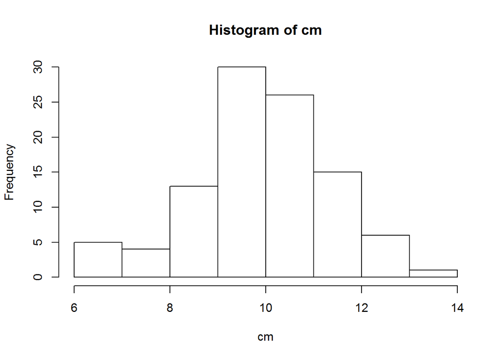

```r
hist(cm)
```

All of the standard probability distributions are built into R, including exponential (rexp()), chi-squared (rchisq()), gamma (rgamma()), …. Well, you see the pattern.

Simulation is practically a field of its own and we’ve only skimmed the surface of what’s possible. I encourage you to explore these and other functions further on your own.